# Clear Creek

Sadie Gill, Mark Tompkins

July 2020

## Future Data Improvements

None planned.

## Instream Spawning and Rearing Habiat

**Data Source:** [FWS 2007](https://www.fws.gov/lodi/instream-flow/Documents/Clear%20Creek%20Whiskeytown%20to%20Clear%20Creek%20Br%20spawning%20final%20report.pdf) (pgs 113-117) and [FWS Rearing 2011](https://www.fws.gov/lodi/instream-flow/Documents/Clear%20Creek%20Whiskeytown%20to%20Clear%20Creek%20Br%20rearing%20final%20report.pdf) (pgs 144-157) and [FWS Spawning 2011](https://www.fws.gov/lodi/instream-flow/Documents/Clear%20Creek%20Lower%20Spawning%20Final%20Report.pdf) (pgs 107-109) and [FWS 2013](https://www.fws.gov/lodi/instream-flow/Documents/Clear%20Creek%20Lower%20Rearing%20Final%20Report-1.pdf) (pgs 150-160)

Instream spawning and rearing habitat for Fall Run Chinook Salmon, Spring Run Chinook Salmon, and Steelhead in Clear Creek are based on data from four U.S. Fish and Wildlife Service (USFWS) instream flow evaluations. The data were collected between 2007 and 2013 for the Central Valley Project Improvement Act (CVPIA). These evaluations uncovered relationships between flow and suitable spawning and rearing habitat area for “upper” (Whiskeytown Dam to Clear Creek Road) and “lower” (Clear Creek Road to the Sacramento River) Clear Creek. The original data can be found on pages 113 - 117 of FWS 2007 (Upper Clear Creek spawning), pages 144 - 157 of FWS Rearing 2011 (Upper Clear Creek rearing, pages 107 - 109 of FWS Spawning 2011 (Lower Clear Creek spawning), and pages 150 - 160 of FWS 2013 (Lower Clear Creek rearing). Mark Gard from the California Department of Fish and Wildlife combined the habitat data from these four studies into a [spreadsheet](https://cvpiahabitat-r-package.s3-us-west-2.amazonaws.com/IFIMWUA.xlsx) for the entire Clear Creek watershed. Mark Gard instructed us to use A3:G26, A30:G53, and A58:G81 of the ‘Clear’ tab within the spreadsheet. These cells represent the weighted usable area (WUA) in square feet for the lower alluvial (8.81 mi), canyon (7.33 mi), and upper alluvial (2.27 mi) segments. Fall Run are only present in the lower alluvial segment. The Fall Run spawning data are an estimate provided by Clear Creek watershed experts upon receiving feedback that the FWS estimates had been too low.

### Combine Spawning and Rearing Data

The instream spawning and rearing habitat data described above for Fall Run Chinook Salmon (FR), Spring Run Chinook Salmon (SR), and Steelhead (ST) is combined for use in the Decision Support Model (DSM) in the following format. Units are in square feet per 1000 feet.

Header Descriptions: flow_cfs = flow in cubic feet per second, FR_spawn_wua = Fall Run Chinook Spawning WUA, FR_fry_wua = Fall Run Chinook Fry wua, FR_juv_wua = Fall Run Chinook Juvenile WUA, SR_spawn_wua = Spring Run Chinook Spawning WUA, SR_fry_wua = Spring Run Chinook Fry WUA, SR_juv_wua = Spring Run Chinook Juvenile WUA, ST_spawn_wua = Steelhead Spawning WUA, ST_fry_wua = Steelhead Fry WUA, ST_juv_wua = Steelhead Juvenile WUA, watershed = section of stream modeled for CVPIA SDM

| flow_cfs | FR_spawn_wua | FR_fry_wua | FR_juv_wua | SR_spawn_wua | SR_fry_wua | SR_juv_wua | ST_spawn_wua | ST_fry_wua | ST_juv_wua | watershed |
| --- | --- | --- | --- | --- | --- | --- | --- | --- | --- | --- |
| 50 | 13000 | 11526.29 | 4835.135 | 34.26847 | 3138.600 | 1862.912 | 266.3449 | 2308.075 | 1862.912 | Clear Creek |
| 75 | 13000 | 11367.48 | 5341.167 | 65.47901 | 3094.353 | 2379.461 | 410.8645 | 2287.449 | 2379.461 | Clear Creek |
| 100 | 13000 | 11082.30 | 5753.491 | 98.36648 | 3115.875 | 2843.080 | 538.2142 | 2211.300 | 2843.080 | Clear Creek |
| 125 | 13000 | 10788.47 | 6089.671 | 128.31439 | 3178.732 | 3259.325 | 652.2620 | 2174.255 | 3259.325 | Clear Creek |
| 150 | 13000 | 10549.26 | 6381.845 | 156.80240 | 3192.209 | 3639.398 | 751.0534 | 2151.992 | 3639.398 | Clear Creek |

*… with 18 more rows*

### Spawning WUA

The following plot shows the weighted usable spawning area (WUA) in square feet per thousand feet for Fall Run Chinook salmon, Spring Run Chinook Salmon, and Steelhead. These area per length rates are multiplied by the total spawning reach length mapped by the Science Integration Team (SIT) to estimate available habitat.

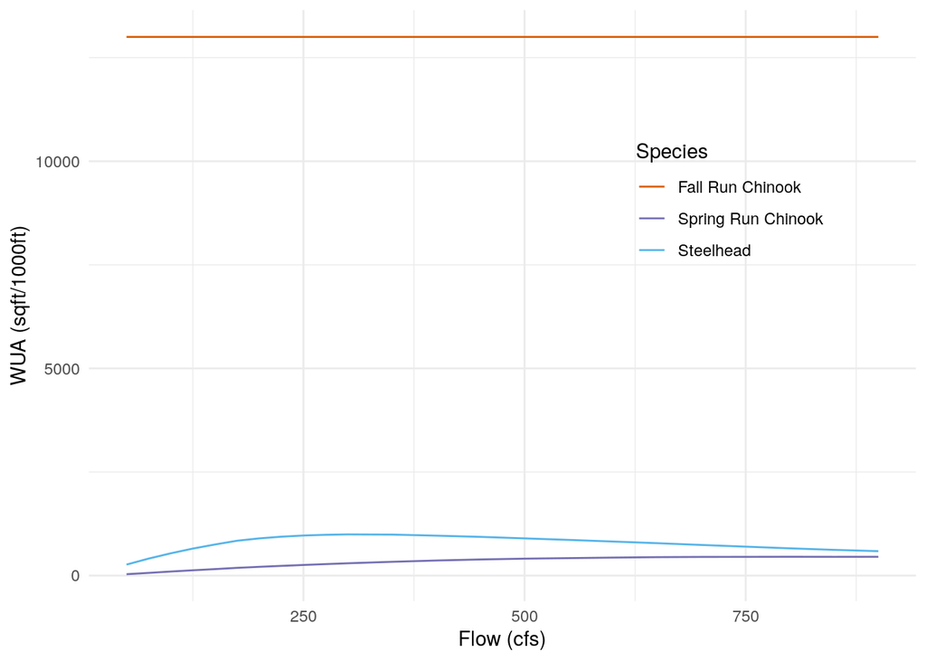

### Rearing WUA

The following plot shows the rearing WUA in square feet per thousand feet for Fall Run Chinook Salmon, Spring Run Chinook Salmon, and Steelhead fry and juvenile. The juvenile rearing data are the same for Spring Run and Steelhead. These rates are multiplied by the total rearing reach length mapped by the SIT to estimate available habitat.

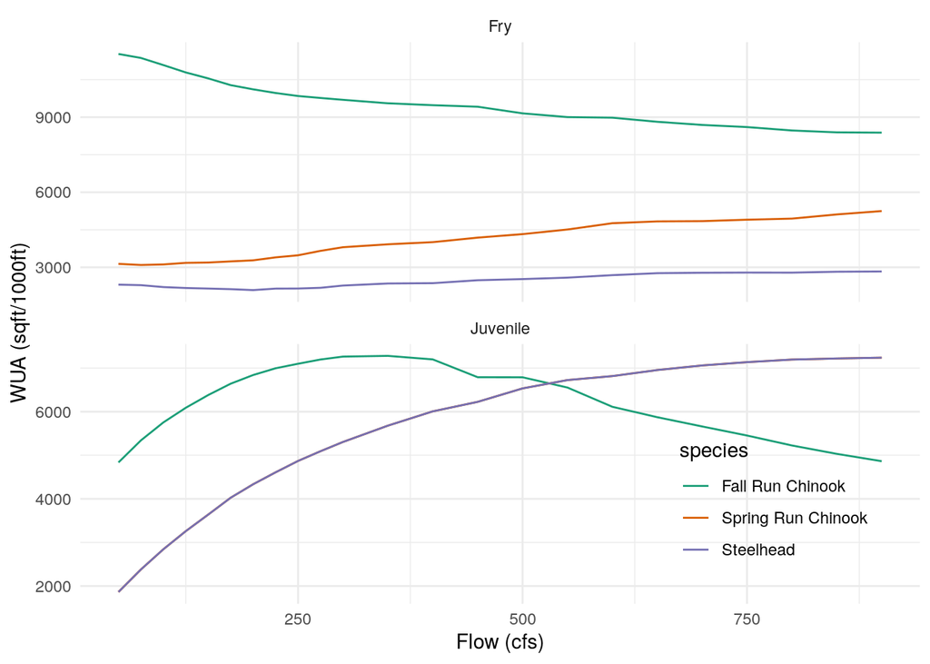

## Floodplain Rearing Habitat

**Data Source:** [Scaled USFWS / FEMA 1D HEC-RAS hydraulic model](https://s3-us-west-2.amazonaws.com/cvpiahabitat-r-package/cvpia-sit-model-inputs/CVPIA+Annual+Progress+Report+Fiscal+Year+2017.pdf)

### Fall Run

There was no watershed specific hydraulic modeling available for Clear Creek. A flow to inundated floodplain area relationship was generated for Clear Creek by scaling the flow to inundated floodplain area relationship for Cottonwood Creek. This scaling used the ratio of mean flow from December to June between the modeled and unmodeled watershed. Flows and corresponding inundated floodplain areas per unit length were calculated for Clear Creek as 21% of Cottonwood Creek. Of the entire mapped 8 miles rearing extent in Clear Creek, 8 miles were classified as low gradient and 0 miles were classified as high gradient based on a geomorphic analysis of long profile slopes and valley widths. The area per unit length was scaled by a factor of 0.1 for the high gradient extent. There was no scaling factor applied to the low gradient extent.

### Spring Run and Steelhead

There was no watershed specific hydraulic modeling available for Clear Creek. A flow to inundated floodplain area relationship was generated for Clear Creek by scaling the flow to inundated floodplain area relationship for Cottonwood Creek. This scaling used the ratio of mean flow from December to June between the modeled and unmodeled watershed. Flows and corresponding inundated floodplain areas per unit length were calculated for Clear Creek as 21% of Cottonwood Creek. Of the entire mapped 17.9 miles rearing extent in Clear Creek, 8 miles were classified as low gradient and 9.9 miles were classified as high gradient based on a geomorphic analysis of long profile slopes and valley widths. The area per unit length was scaled by a factor of 0.1 for the high gradient extent. There was no scaling factor applied to the low gradient extent.

## Floodplain Data

The areas represent total inundated area in acres.

Header Descriptions: flow_cfs = flow in cubic feet per second, FR_floodplain_acres = Fall Run Chinook floodplain acres, SR_floodplain_acres = Spring Run Chinook floodplain acres, ST_floodplain_acres = Steelhead floodplain acres, watershed = section of stream modeled for CVPIA SDM

| flow_cfs | FR_floodplain_acres | SR_floodplain_acres | ST_floodplain_acres | watershed |
| --- | --- | --- | --- | --- |
| 1590.201 | 0.0000000 | 0.0000000 | 0.0000000 | Clear Creek |
| 1665.526 | 0.4424499 | 0.4973432 | 0.4973432 | Clear Creek |
| 1740.852 | 0.9927313 | 1.1158963 | 1.1158963 | Clear Creek |
| 1816.177 | 1.4421274 | 1.6210475 | 1.6210475 | Clear Creek |
| 1891.502 | 1.8118601 | 2.0366519 | 2.0366519 | Clear Creek |

*… with 5 more rows*

## Floodplain Plot

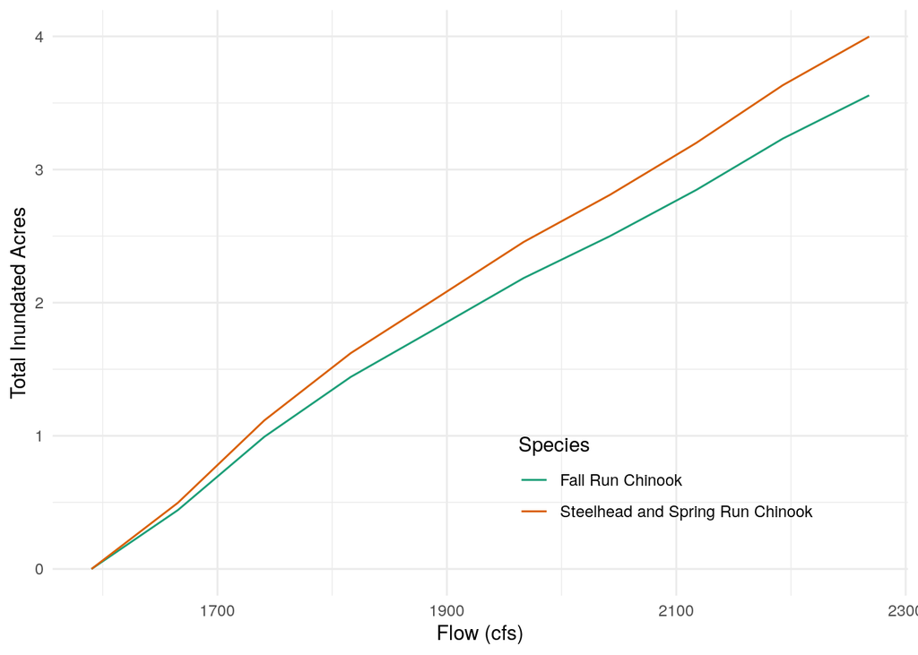